# Projective Geometry and Transformations of 2D

### Contents

1. Points and Lines
2. Ideal Points and line at infinity
3. Conics and dual Conics
4. Projective transformations
5. Recovery of affine and metric properties from images

Before diving into Projective Geometry. First we need to understand what is Homogeneous Coordinates? Homogeneous Coordinates are predominantly used in *photogrammetry, computer vision, and robotics* because this will help us to do certain tasks( such as camera calibration, pose estimation of a camera) more elegantly than comparing with *Euclidean Coordinates.* And this helps us to represent the geometry of infinitely far way objects with finite numbers. These finite numbers representation becomes handy when dealing with problems like state estimation.

why the projective space uses homogeneous coordinates are because the if we take the pin-hole camera model. The 3 dimensional points are projected on to the 2 dimensional space. Before jumping into the homogeneous coordinates first we need to understand what is projective space or transformation. Look at a picture, we see squares that are not squares, or circles that are not circles. The transformation that maps these planar objects onto the picture is an example of a projective transformation.

**So what properties of geometry are preserved by projective transformations?**

- Certainly, shape is not, since a circle may appear as an ellipse.
- Neither are lengths since two perpendicular radii of a circle are stretched by different amounts by the projective transformation.
- Angles, distance, ratios of distances – none of these are preserved.
- *However, a property that is preserved is that of straightness*.

Euclidean geometry is troublesome in one major respect – we need to keep making an exception to reason about some of the basic concepts of the geometry – such as intersection of lines. Two lines almost always meet in a point, but there are some pairs of lines that do not do so – those that we call parallel. A common linguistic device for getting around this is to say that **parallel lines meet “at infinity”.** However this is not altogether convincing, and conflicts with another dictum, that infinity does not exist, and is only a convenient fiction.

We can get around this by enhancing the Euclidean plane by the addition of these points at infinity where parallel lines meet, and resolving the difficulty with infinity by calling them **“ideal points.”**

Now we might have got an idea of how to represent the points at infinity, if we migrate to another space instead of being in euclidean space. So homogeneous coordinates are represented very simple, just adding one more dimension to our normal euclidean coordinates, for example we have point $(x,y)$ on plane, then the homogeneous representation is simple $(x,y,1)$

We now take the important conceptual step of asking why the last coordinate needs to be 1 – after all, the others two coordinates are not so constrained. What about a coordinate triple $(x, y, 2)$. It is here that we make a definition and say that $(x, y, 1)$ and $(2x, 2y, 2)$ represent the same point, and furthermore, $(kx, ky, k)$ represents the same point as well, for any non-zero value $k$. Formally, points are represented by equivalence classes of coordinate triples, where two triples are equivalent when they differ by a common multiple. These are called the homogeneous coordinates of the point. Given a coordinate triple $(kx, ky, k)$, we can get the original coordinates back by dividing by $k$ to get $(x, y)$. **If we try to divide by the last coordinate, we get the point $(x/0, y/0)$ which is infinite. This is how the points at infinity arise then. They are the points represented by homogeneous coordinates in which the last coordinate is zero.**

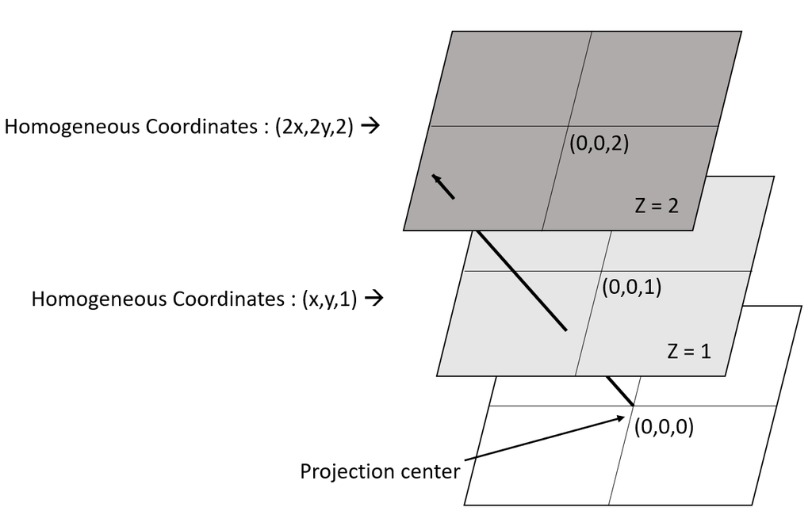

### Points and Lines

A line $l$ in ${\Re}^{2}$ is a set of points $(x,y) \in {\Re}^2$ that obeys the equation $ax + by + c = 0$ for some values of the parameters $a,b,c \in \Re$. Lets represent the 2D physical point $(x,y)$ in homogenous coordinate system as $(x,y,1)$ and our line parameter vector as $\begin{pmatrix} a \\ b \\ c\end{pmatrix}$

obviously, the algebraic equation of a line, $ax+by+c=0$, can be expressed as: $l^T.x=0$ or $x^T.l=0$. Exploring the 3D representation space $\Re^3$ we note that the for any multiple $k \in \Re, k\neq0$ and $k\begin{pmatrix}x \\y\\1\end{pmatrix}$ is same physical point in $\Re^2$ as that corresponding to $\begin{pmatrix}x \\y\\1\end{pmatrix}$

so in the $\Re^2$ representational space, all the points $k\begin{pmatrix}x \\y\\1\end{pmatrix}$, with $k\neq0$ form an equivalence class, in the sense they represent same physical point $(x,y) \in \Re^2$. That is each radial line passing through the orgin but not including the orgin, in $\Re^3$ represents a unique physical point in $\Re^2$

**Here are a couple of immediate payoffs of our Homogeneous Implementation for points and lines in physical $\Re^2$:**

- Given any 2 lines $l_1=\begin{pmatrix}a_1 \\b_1\\c_1\end{pmatrix}$ and $l_2=\begin{pmatrix}a_2\\b_2\\c_2\end{pmatrix}$ then the point of intersection is given by their vector cross product $x=l_1 \times l_2 = \begin{pmatrix}a_1 \\b_1\\c_1\end{pmatrix} \times \begin{pmatrix}a_2\\b_2\\c_2\end{pmatrix} = \begin{pmatrix}b_1c_2-b_2c_1\\a_1c_2-a_2c_1\\a_1b_2-a_2b_1\end{pmatrix}$
- Given any 2 points $x_1=\begin{pmatrix}x_1 \\y_1\\1\end{pmatrix}$ and $x_2=\begin{pmatrix}x_2\\y_2\\1\end{pmatrix}$ then the line formed by joining these 2 points is given by their vector cross product $l=x_1 \times x_2 = \begin{pmatrix}x_1 \\y_1\\1\end{pmatrix} \times \begin{pmatrix}x_2\\y_2\\1\end{pmatrix} = \begin{pmatrix}y_1-y_2\\x_1-x_2\\x_1y_2-x_2y_1\end{pmatrix}$
- Both the above assertions follow immediately from the triple scalar product indentity $\overrightarrow{A}.(\overrightarrow{A} \times \overrightarrow{B})\equiv\overrightarrow{B}.(\overrightarrow{A} \times \overrightarrow{B})\equiv0$

### Ideal Points and line at infinity

##### Intersection of Parallel lines

we know that slope of line $(ax+by+c=0)$ or $(a,b,c)$ in $\Re^2$ is given by $\frac{a}{b}$ the 2 distinct parallel lines will be $l_1=\begin{pmatrix}a\\b\\c_1\end{pmatrix}$ and $l_2=\begin{pmatrix}a\\b\\c_2\end{pmatrix}$. We can easily show that the point of intersection of these 2 lines is $x=\begin{pmatrix}b(c_2-c_1)\\-a(c_2-c_1)\\0\end{pmatrix}$. Hence we can see that the 3rd coordinate is zero, which implies that parallel lines meet at infinity and we can represent this easily with the help of homogeneous coordinate without any approximation

##### Ideal points and line at infinity

Here is something to keep you awake at night : All **Ideal Points** form a straight line in $\Re^2$ and line represented in homogeneous coordinate vector will be $\begin{pmatrix}0\\0\\1\end{pmatrix}$  
To prove above statement let's take 2 ideal points $x_1=\begin{pmatrix}x_1\\y_1\\0\end{pmatrix}$ and $x_2=\begin{pmatrix}x_2\\y_2\\0\end{pmatrix}$, then their cross product will be $x_1 \times x_2 = \begin{pmatrix}0\\0\\x_1y_2-x_2y_1\end{pmatrix}$ after normalizing with 3rd component, it'll be $\begin{pmatrix}0\\0\\1\end{pmatrix}$. This Unique line is referred as **line at infinity ($l_\infty$)**. This $l_\infty$ will play a important role in our camera models which is also called as **vanishing line**  
If we want visualise it please imagine your standing on a infinte plane and if you look for the horizon on any direction it'll be looking like a line.

### Conics and dual Conics

A conic is a curve described by a second-degree equation in the plane. In Euclidean geometry conics are of three main types: hyperbola, ellipse, and parabola (apart from so-called degenerate conics, to be defined later). Classically these three types of conic arise as conic sections generated by planes of differing orientation (the degenerate conics arise from planes which contain the cone vertex).
The equation of a conic in inhomogeneous coordinates is: $$ax^2+bxy+cy^2+dx+ey+f=0$$
i.e. a polynomial of degree 2. “Homogenizing” this by the replacements: $x → x1/x3, y → x2/x3$ gives $$a{x_1}^2+b{x_1}{x_2}+c{x_2}^2+d{x_1}{x_3}+e{x_2}{x_3}+f{x_3}^2=0$$
if we want to visualise conics in matrix form for the point $x = (x_1,x_2,x_3)$ : $$xCx^T = 0, C = \begin{pmatrix}a&b/2&d/2\\b/2&c&e/2\\d/2&e/2&f\end{pmatrix}\leftarrow symmetric$$

[figure not shown]

image courtesy: Wikipedia

##### Tangent lines to conics

**The line l tangent to C at a point x on C is given by l = Cx**  
To prove the above statement lets consider from the above statement that $x = \begin{pmatrix}x_1\\x_2\\x_3\end{pmatrix}$ lies on both line $l = \begin{pmatrix}a\\b\\c\end{pmatrix}$ and on conic $C = \begin{pmatrix}a&b/2&d/2\\b/2&c&e/2\\d/2&e/2&f\end{pmatrix}$. Now we know that $l^T.x=0$, so applying the above in this equation we get $l^T.x = (C.x)^T.x = x^TC^Tx = x^TCx = 0$, since $C$ is symmetric

##### Degenerate Conics

when we slice the double cone with a plane, which passes exactly through the axis or vertex of double cones, instead of seeing hyperbola, you will now see two interesting straight lines, which are intersecting exactly at vertex. We say these lines constitute a degenerate conic.

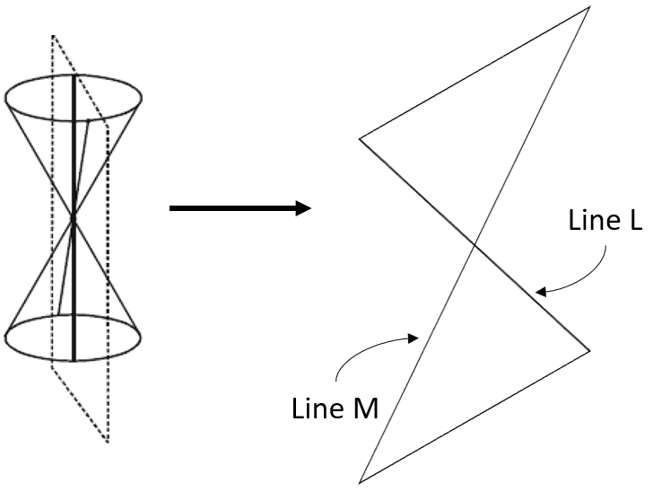

when plane slices the double cone exactly at vertex

Let line L and M represent in homogeneous coordinate of degenerate conic. That is every point on the degenerate conic is on either line L or line M, we can show that such a conic $C$ is given by: $$C = lm^T + ml^T$$
it is trivial to show that such a $C$ satisfies the conic equation $x^TCx = 0 ,\forall x$ lies on line $l$ and satisfies the conic equation $x^TCx = 0, \forall x$ lies on line $m$
Note: Each of the two terms in above addition is outer product and each matrix has rank of 1, so when it is combined with addition the rank becomes 2. [please click here to get to know about final rank - when unity rank matrices are added](https://math.stackexchange.com/a/707216)
we might get a doubt why the rank of outer product vectors is 1?
Lets resolve that, consider line $l = \begin{pmatrix} l_1\\l_2\\l_3 \end{pmatrix}$ and $m = \begin{pmatrix} m_1\\m_2\\m_3 \end{pmatrix}$, their outer product is $lm^T = \begin{pmatrix} l_1\\l_2\\l_3 \end{pmatrix}\begin{pmatrix} m_1 & m_2 & m_3 \end{pmatrix} = \begin{pmatrix} l_1m_1 & l_1m_2 & l_1m_3\\l_2m_1 & l_2m_2 & l_2m_3\\l_3m_1 & l_3m_2 & l_3m_3 \end{pmatrix}$
where we can see that every column is constant multiple of $m_1/m_2$ or $m_1/m_3$ other.

### Projective transformations

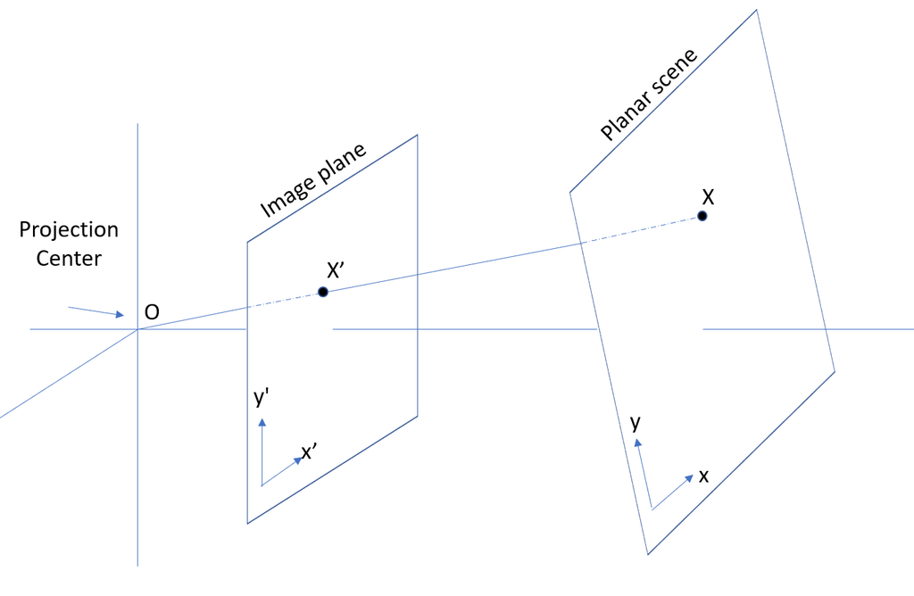

**Project Transform** is an invertible mapping from points in a plane $\wp^2$ to the points in another plane $\wp^2$ that maps lines to lines. There are totally 4 projective transforms namely, isometry, similarity, affine, and projective. **Projectivity** is a linear transformation on homogeneous 3-vectors represented by a non-singular $3\times3$ matrix

##### Isometrics transform

Isometries are transformations of the plane $\Re^2$ that preserve Euclidean distance (from iso = same, metric = measure). An isometry is represented as: $$\begin{pmatrix}x'\\y'\\1\end{pmatrix} = \begin{pmatrix}\epsilon\cos\theta&-\sin\theta&t_x\\\epsilon\sin\theta&\cos\theta&t_y\\0&0&1\end{pmatrix}\begin{pmatrix}x\\y\\1\end{pmatrix}$$ where $\epsilon = ±1$. If $\epsilon = 1$, then the isometry is orientation preserving and is a Euclidean transformation (a composition of a translation and rotation). On the other hand, if $\epsilon = -1$, then the isometry reverses orientation. An example is a transformation which performs a simple reflection.

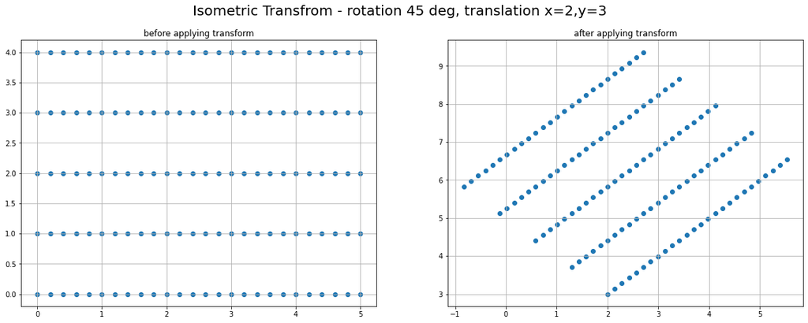

```python
import matplotlib.pyplot as plt
import numpy as np
in_points = np.column_stack((np.tile(np.arange(0,5.1,0.2),5),np.concatenate([0*np.ones(26),1*np.ones(26),2*np.ones(26),3*np.ones(26),4*np.ones(26)]),np.ones(130)))
########################## inputs for H matrix ###############################
degrees = 45; tx=2; ty = 3
H_matrix = np.array([[np.cos(np.deg2rad(degrees)), -np.sin(np.deg2rad(degrees)), tx],
                     [np.sin(np.deg2rad(degrees)),  np.cos(np.deg2rad(degrees)), ty],
                     [                          0,                            0,  1]])
##############################################################################
out_points = np.matmul(H_matrix,in_points.T).T
fig, ax = plt.subplots(nrows=1, ncols=2, figsize = (20,7))
ax[0].grid()
ax[0].scatter(in_points[:,0],in_points[:,1])
ax[0].title.set_text("before applying transform")
ax[1].grid()
ax[1].scatter(out_points[:,0],out_points[:,1])
ax[1].title.set_text("after applying transform")
plt.suptitle("Isometric Transfrom - rotation 45 deg, translation x=2,y=3",fontsize=20)
```

##### similarity transform

A similarity transformation (or more simply a similarity) is an isometry composed with an isotropic scaling. In the case of a Euclidean transformation composed with a scaling (i.e. no reflection) the similarity has matrix representation: $$\begin{pmatrix}x'\\y'\\1\end{pmatrix} = \begin{pmatrix}s\cos\theta&-s\sin\theta&t_x\\s\sin\theta&s\cos\theta&t_y\\0&0&1\end{pmatrix}\begin{pmatrix}x\\y\\1\end{pmatrix}$$ This can be written more concisely in block form as: $$X' = H_s.X =\begin{pmatrix}sR&t\\0^T&1\end{pmatrix}$$

##### Affine transform

An affine transformation (or more simply an affinity) is a non-singular linear transformation followed by a translation. It has the matrix representation: $$\begin{pmatrix}x'\\y'\\1\end{pmatrix} = \begin{pmatrix}a_{11}&a_{12}&t_x\\a_{21}&a_{22}&t_y\\0&0&1\end{pmatrix}\begin{pmatrix}x\\y\\1\end{pmatrix}$$ This can be written more concisely in block form as: $$X' = H_a.X =\begin{pmatrix}A&t\\0^T&1\end{pmatrix}$$with A a $2 \times 2$ non-singular matrix

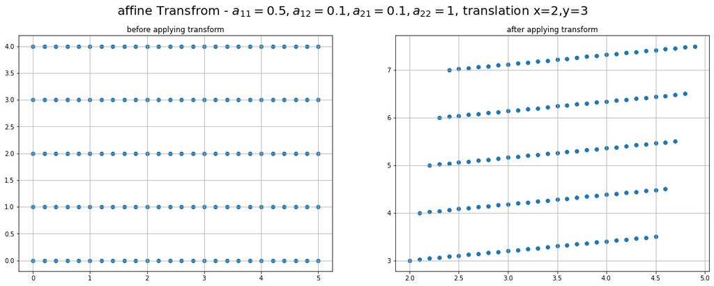

```python
########################## inputs for H matrix ###############################
tx=2; ty = 3
H_matrix = np.array([[0.5, 0.1, tx],
                     [0.1,   1, ty],
                     [  0,   0,  1]])
##############################################################################
out_points = np.matmul(H_matrix,in_points.T).T
fig, ax = plt.subplots(nrows=1, ncols=2, figsize = (20,7))
ax[0].grid()
ax[0].scatter(in_points[:,0],in_points[:,1])
ax[0].title.set_text("before applying transform")
ax[1].grid()
ax[1].scatter(out_points[:,0],out_points[:,1])
ax[1].title.set_text("after applying transform")
plt.suptitle("affine Transfrom - $a_{11}=0.5,a_{12}=0.1,a_{21}=0.1,a_{22}=1$, translation x=2,y=3",fontsize=20)
```

##### Projective transform

It is a general non-singular linear transformation of homogeneous coordinates. This generalizes an affine transformation, which is the composition of a general non-singular linear transformation of inhomogeneous coordinates and a translation. $$\begin{pmatrix}x'\\y'\\1\end{pmatrix} = \begin{pmatrix}a_{11}&a_{12}&t_x\\a_{21}&a_{22}&t_y\\v_1&v_2&1\end{pmatrix}\begin{pmatrix}x\\y\\1\end{pmatrix}$$ This can be written more concisely in block form as: $$X' = H_p.X =\begin{pmatrix}A&t\\v^T&1\end{pmatrix}$$

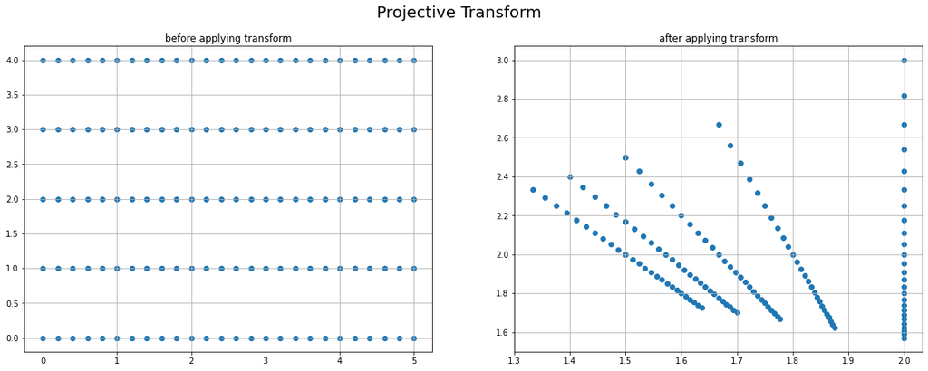

```python
########################## inputs for H matrix ###############################
H_matrix = np.array([[1, 0.5, tx],
                     [0.5, 1, ty],
                     [0.5,  0.5,  1]])
##############################################################################
out_points = np.matmul(H_matrix,in_points.T).T
out_points = np.column_stack(((out_points[:,0]/out_points[:,2]),(out_points[:,1]/out_points[:,2]),(out_points[:,2]/out_points[:,2])))
fig, ax = plt.subplots(nrows=1, ncols=2, figsize = (20,7))
ax[0].grid()
ax[0].scatter(in_points[:,0],in_points[:,1])
ax[0].title.set_text("before applying transform")
ax[1].grid()
ax[1].scatter(out_points[:,0],out_points[:,1])
ax[1].title.set_text("after applying transform")
plt.suptitle("Projective Transform",fontsize=20)
```

[image courtesy: Daniel Lenton](https://medium.com/@daniel.j.lenton/part-ii-projective-transformations-in-2d-2e99ac9c7e9f)

[figure not shown]

Projective Transform step by step procedure

### Recovery of affine and metric properties from images

Under a **projective transformation ideal points are mapped to finite points**, and consequently $l_\infty$ is mapped to a finite line. However, if the transformation is an affinity, then $l_\infty$ is not mapped to a finite line, but remains at infinity. To Prove the above statement, we have to recall that that points $\begin{pmatrix}x\\y\\1\end{pmatrix}$ are transformed according to ${H_a} = \begin{pmatrix}A&t\\\overrightarrow 0&1\end{pmatrix}$. Then lines $\begin{pmatrix}a\\b\\c\end{pmatrix}$are transform according to ${H_a}^{-T} = ({H_a}^{-1})^T = \begin{pmatrix}A^{-1}&-A^{-1}t\\\overrightarrow 0&1\end{pmatrix}^T = \begin{pmatrix}A^{-1}&\overrightarrow 0\\(-A^{-1}t)^T&1\end{pmatrix}$. Now we know already that $l_\infty = \begin{pmatrix}0\\0\\1\end{pmatrix}$. so this $l_\infty$ will remain $l_\infty$ even after applying ${H_a}^{-T}\begin{pmatrix}0\\0\\1\end{pmatrix} = \begin{pmatrix}0\\0\\1\end{pmatrix}$  
whereas every affine transform will map $l_\infty$ to $l_\infty$, a general projective transform will map $l_\infty$ to **vanishing line**. Now from this we can understand the interesting part is we apply inverse projective transform, then physical vanishing line will be mapped to $l_\infty$. So the remaining part will only affine transformation

##### Removing the projective distortion

Let's consider the vanishing line is $l_\infty = \begin{pmatrix}l_1\\l_2\\l_3\end{pmatrix}$. The Homography which takes back the vanishing line to $l_\infty$ is $H_p = \begin{pmatrix}1&0&0\\0&1&0\\l_1&l_2&l_3\end{pmatrix}$  
To prove the above statement lets recall that lines are transformed ${H_p}^{-T} = ({H_p}^{-1})^T = \begin{pmatrix}1&0&0\\0&1&0\\-l_1/l_3&-l_2/l_3&1/l_3\end{pmatrix}^T = \begin{pmatrix}1&0&-l_1/l_3\\0&1&-l_2/l_3\\0&0&1/l_3\end{pmatrix}$. So we prove that ${H_p}^{-T}\begin{pmatrix}l_1\\l_2\\l_3\end{pmatrix} = \begin{pmatrix}0\\0\\1\end{pmatrix}$. Now we understood that with the help of projective transform and $l_\infty$ we can convert to affine, but there is primary manifestation of which is unequal scaling of two orthogonal directions in the image. To remove those distortions we need to additional tools - that require to understand the principle of duality with respect to points and lines in projective geometry.

##### Principle of points/line Duality in Homogeneous Coordinate

- The key result is that line joining two points $X_1$ and $X_2$ is given by $l = X_1 \times X_2$ and point of intersection of two lines $L_1$ and $L_2$ is given by $X = L_1 \times L_2$
- we can take any relation in homogeneous coordinate formulation of projective geometry an obtain its dual by switching points and lines
- Another reason for point/line duality is because we can define 2D plane either with points or lines, for example see the below picture of a conic

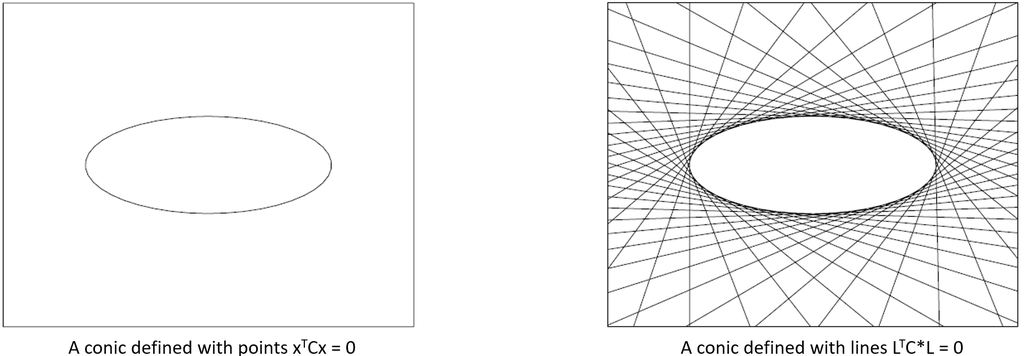

  image courtesy : Andrew Zisserman
- The Tangent line to conic $C$ at its perimeter point x is given by $l = Cx$. Therefore $x=C^{-1}l$, implying that $(C^{-1}l)^TC(C^{-1}l)$ and since $C$ is symmetric we $l^{-T}C^{-1}l = 0$, which implies $C^* = C^{-1}$, where $C^*$ is adjoint matrix

#### Salutations

1. [Photogrammetric Computer Vision: Statistics, Geometry, Orientation and Reconstruction, by Wolfgang Förstner , Bernhard P. Wrobel](https://www.amazon.in/Photogrammetric-Computer-Vision-Orientation-Reconstruction-ebook/dp/B01LXFI2XF)
2. [Multiple View Geometry in Computer Vision (Second Edition), by Andrew Zisserman](https://www.amazon.in/Multiple-View-Geometry-Computer-Vision/dp/0521540518)